# Assignment 4

Brenden Hale

10/27/2022

```r
library(tidyverse)  # data manipulation
library(factoextra) # clustering algorithms & visualization
library(ISLR)
library(cluster)
set.seed(123)
```

```r
# Load Pharmaceuticals.csv
Pharmaceuticals <- read.csv("Pharmaceuticals.csv")
```

# A. Use only the numerical variables (1 to 9) to cluster the 21 firms. Justify the various choices made in conducting the cluster analysis, such as weights for different variables, the specific clustering algorithm(s) used, the number of clusters formed, and so on.

```r
# Use only the numerical variables (3-11)
Pharma <- na.omit(Pharmaceuticals)
df <- Pharma[,c(3:11)]
summary(df)
```

```
   Market_Cap          Beta           PE_Ratio          ROE            ROA        Asset_Turnover
 Min.   :  0.41   Min.   :0.1800   Min.   : 3.60   Min.   : 3.9   Min.   : 1.40   Min.   :0.3
 1st Qu.:  6.30   1st Qu.:0.3500   1st Qu.:18.90   1st Qu.:14.9   1st Qu.: 5.70   1st Qu.:0.6
 Median : 48.19   Median :0.4600   Median :21.50   Median :22.6   Median :11.20   Median :0.6
 Mean   : 57.65   Mean   :0.5257   Mean   :25.46   Mean   :25.8   Mean   :10.51   Mean   :0.7
 3rd Qu.: 73.84   3rd Qu.:0.6500   3rd Qu.:27.90   3rd Qu.:31.0   3rd Qu.:15.00   3rd Qu.:0.9
 Max.   :199.47   Max.   :1.1100   Max.   :82.50   Max.   :62.9   Max.   :20.30   Max.   :1.1
    Leverage        Rev_Growth    Net_Profit_Margin
 Min.   :0.0000   Min.   :-3.17   Min.   : 2.6
 1st Qu.:0.1600   1st Qu.: 6.38   1st Qu.:11.2
 Median :0.3400   Median : 9.37   Median :16.1
 Mean   :0.5857   Mean   :13.37   Mean   :15.7
 3rd Qu.:0.6000   3rd Qu.:21.87   3rd Qu.:21.1
 Max.   :3.5100   Max.   :34.21   Max.   :25.5
```

```r
# Scaling the data frame's numerical variables
df.scale <- scale(df)
```

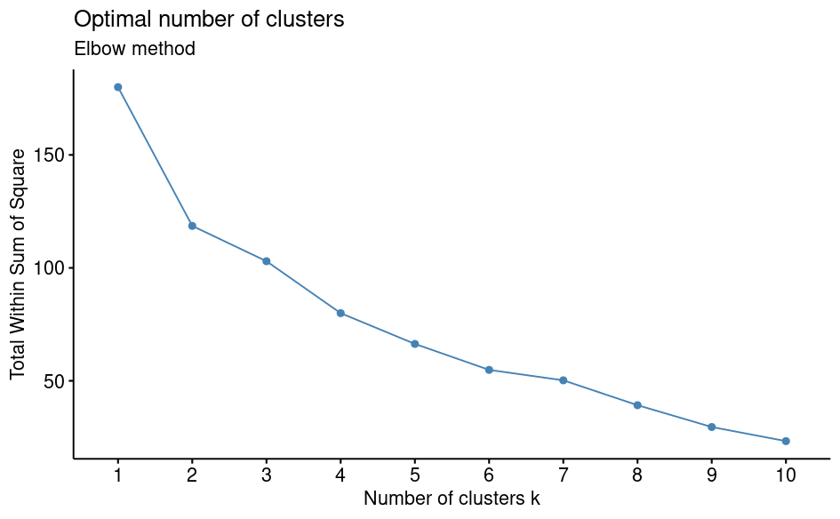

```r
# In order to find the optimal number of cluters, I will use the Elbow and Silhouette methods. The Elbow is one of the most popular methods but it is inexact. The Silhouette provides a more exact visual of the optimal number of clusters and is fairly straightforward.

# Elbow method to determine clusters
fviz_nbclust(df.scale, kmeans, method = "wss") + labs(subtitle = "Elbow method")
```

```r
# The eblow appears to pivot at k=4 or k=5
```

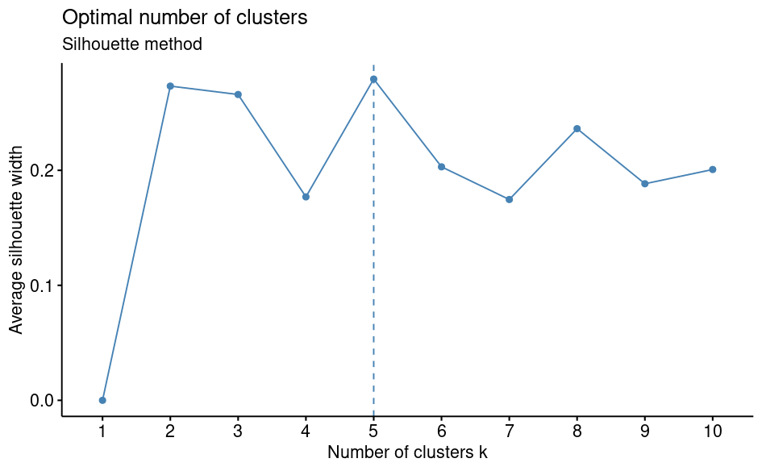

```r
# Silhouette method to determine clusters
fviz_nbclust(df.scale, kmeans, method = "silhouette")+ labs(subtitle = "Silhouette method")
```

```r
# According to the Silhouette method 5 is the optimal number of clusters
```

```r
# According to the Elbow and Silhouette method shown above, the optimal number of clusters is 5

k5 <- kmeans(df.scale,centers = 5,nstart = 25)
```

```r
k5$centers # Centroids for clusters
```

```
   Market_Cap       Beta    PE_Ratio        ROE        ROA Asset_Turnover    Leverage Rev_Growth
1 -0.03142211 -0.4360989 -0.31724852  0.1950459  0.4083915      0.1729746 -0.27449312 -0.7041516
2 -0.87051511  1.3409869 -0.05284434 -0.6184015 -1.1928478     -0.4612656  1.36644699 -0.6912914
3 -0.43925134 -0.4701800  2.70002464 -0.8349525 -0.9234951      0.2306328 -0.14170336 -0.1168459
4  1.69558112 -0.1780563 -0.19845823  1.2349879  1.3503431      1.1531640 -0.46807818  0.4671788
5 -0.76022489  0.2796041 -0.47742380 -0.7438022 -0.8107428     -1.2684804  0.06308085  1.5180158
  Net_Profit_Margin
1       0.556954446
2      -1.320000179
3      -1.416514761
4       0.591242521
5      -0.006893899
```

```r
k5$size
```

```
[1] 8 3 2 4 4
```

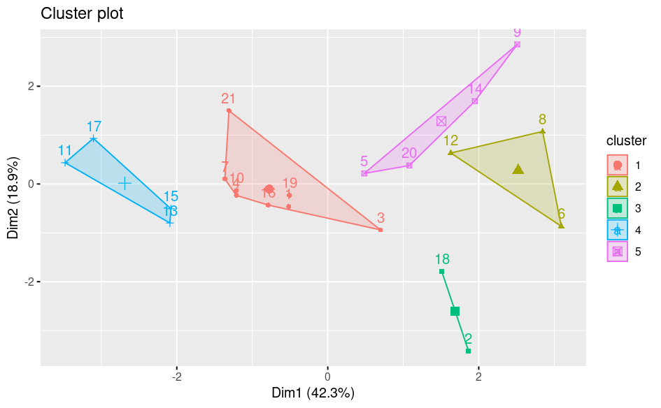

```r
fviz_cluster(k5, data = df.scale) # Visualize clusters
```

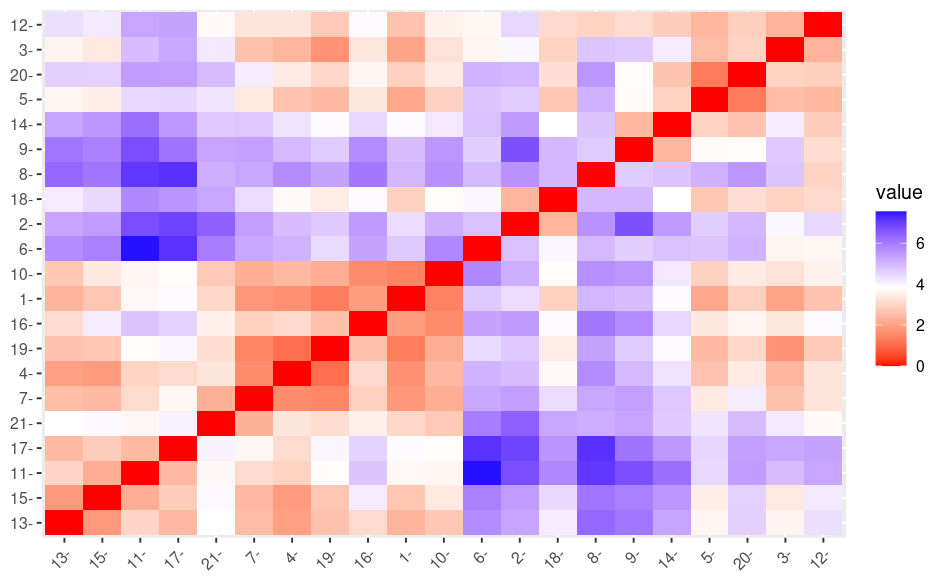

```r
distance <- dist(df.scale, method = "euclidean")
fviz_dist(distance)
```

```r
# Visualizations
fit <- kmeans(df.scale,5) # Use K-means to determine fit of the data
aggregate(df.scale, by = list(fit$cluster), FUN=mean) # Calculate mean of all numerical variables in cluster
```

| Group.1 | Market_Cap | Beta | PE_Ratio | ROE | ROA | Asset_Turnover | Leverage | Rev_Growth | Net_Profit_Margin |
| --- | --- | --- | --- | --- | --- | --- | --- | --- | --- |
| 1 | 0.08926902 | -0.4618336 | -0.3208615 | 0.3260892 | 0.5396003 | 6.589509e-02 | -0.2559803 | -0.7230135 | 0.7343816 |
| 2 | 1.69558112 | -0.1780563 | -0.1984582 | 1.2349879 | 1.3503431 | 1.153164e+00 | -0.4680782 | 0.4671788 | 0.5912425 |
| 3 | -0.96247577 | 1.1949250 | -0.3639982 | -0.5200697 | -0.9610792 | -1.153164e+00 | 1.4773718 | 0.7120120 | -0.3688236 |
| 4 | -0.66114002 | -0.7233539 | -0.3512251 | -0.6736441 | -0.5915022 | -1.537552e-01 | -0.4040831 | 0.6917224 | -0.4005718 |
| 5 | -0.52462814 | 0.4451409 | 1.8498439 | -1.0404550 | -1.1865838 | 1.480297e-16 | -0.3443544 | -0.5769454 | -1.6095439 |

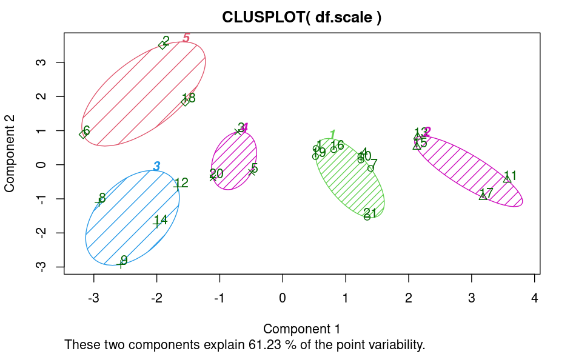

```r
clusplot(df.scale,fit$cluster, color = TRUE, shade = TRUE, labels = 2, lines = 0)
```

# B. Interpret the clusters with respect to the numerical variables used in forming the clusters.

Based off of the cluster plot above: Cluster 1- AZN, ABT, NVS, BMY, WYE, SGP, LLY Cluster 2- GSK, JNJ, MRK, PFE Cluster 3- CHTT, ELN, MRX, IVX Cluster 4- AHM, AVE, WPI Cluster 5- AGN, BAY, PHA

Interpretations based off of data aggregation Cluster 1 has the highest Net_Profit_Margin and the lowest Rev_Growth, Cluster 2 has the highest Market_Cap, ROE, ROA, Asset_Turnover and the lowest Leverage, Cluster 3 has the highest Beta, Leverage, Rev_Growth and the lowest Asset_Turnover, PE_Ratio, Market_Cap Cluster 4 has the lowest Beta Cluster 5 has the highest PE_Ratio and the lowest Net_Profit_Margin, ROA, ROE

# C. Is there a pattern in the clusters with respect to the numerical variables (10 to 12)? (those not used in forming the clusters)

Yes, there is a pattern in regards to the Median_Reccomendation Cluster 1 is primarily a middle ground of a hold with a few a moderate buy or sell Cluster 2, 3 and 5 are mostly a moderate buy Cluster 4 is the most positive buy cluster

# D. Provide an appropriate name for each cluster using any or all of the variables in the dataset.

Cluster 1- High profit low growth Cluster 2- High market cap Cluster 3- Smaller market cap high volatility Cluster 4- Low volatility Cluster 5- High PE